# INN_ABRAHAMTHOMAS_Notebook_Full_code_Final

### Model 3 - Neural Network with Balanced Data (by applying SMOTE) and SGD Optimizer

```python
from imblearn.over_sampling import SMOTE
smote_df  = SMOTE(random_state=1)
X_train_smote, y_train_smote = smote_df.fit_resample(X_train, y_train)
print('After UpSampling,  train_X: {}'.format(X_train_smote.shape))
print('After UpSampling,  train_y: {} \n'.format(y_train_smote.shape))
```

```
After UpSampling,  train_X: (10192, 11)
After UpSampling,  train_y: (10192,)
```

```python
backend.clear_session()
#Fixing the seed for random number generators so that we can ensure we receive the same output everytime
np.random.seed(1)
random.seed(1)
tf.random.set_seed(1)

# init NN
model3 = Sequential()
model3.add(Dense(64,activation='relu',input_dim = X_train_smote.shape[1]))
#hidden layers
model3.add(Dense(32,activation='relu'))
model3.add(Dense(16,activation='relu'))

#output layer
model3.add(Dense(1, activation = 'sigmoid'))
```

```python
model3.summary()
```

```
Model: "sequential"
_________________________________________________________________
 Layer (type)                Output Shape              Param #
=================================================================
 dense (Dense)               (None, 64)                768

 dense_1 (Dense)             (None, 32)                2080

 dense_2 (Dense)             (None, 16)                528

 dense_3 (Dense)             (None, 1)                 17

=================================================================
Total params: 3393 (13.25 KB)
Trainable params: 3393 (13.25 KB)
Non-trainable params: 0 (0.00 Byte)
_________________________________________________________________
```

```python
# SGD optimizer
optimizer = tf.keras.optimizers.SGD()
model3.compile(optimizer = optimizer,loss = 'binary_crossentropy', metrics=[AUC(curve='ROC'), Recall()])
start = time.time()
history3 = model3.fit(X_train_smote, y_train_smote, validation_data=(X_valid,y_valid) , verbose=1, batch_size=batch_size, epochs=epochs,class_weight=cw_dict)
end=time.time()
```

```
Time taken in seconds  82.84826374053955
```

|  | Accuracy | Recall | Precision | F1 Score |
| --- | --- | --- | --- | --- |
| 0 | 0.33 | 0.33 | 0.803792 | 0.301856 |

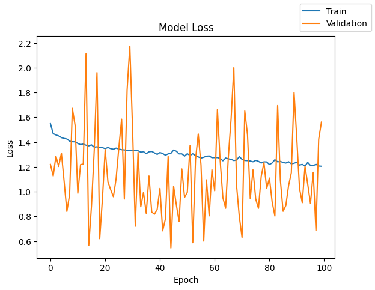

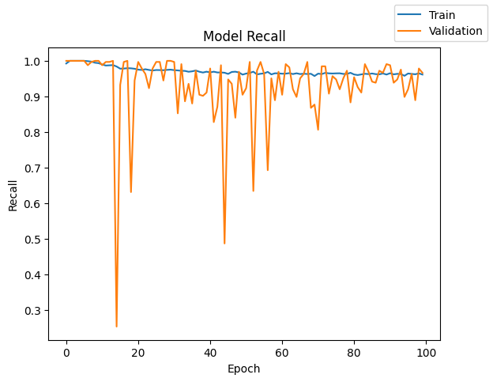

```python
print("Time taken in seconds ",end-start)
#Plotting Train Loss vs Validation Loss
plot(history3,'loss')
plot(history3,'recall')
model_3_train_perf = model_performance_classification(model3, X_train_smote, y_train_smote)
model_3_train_perf

model_3_valid_perf = model_performance_classification(model3, X_valid, y_valid)
model_3_valid_perf
```

```
              precision    recall  f1-score   support

         0.0       0.92      0.17      0.28      5096
         1.0       0.54      0.99      0.70      5096

    accuracy                           0.58     10192
   macro avg       0.73      0.58      0.49     10192
weighted avg       0.73      0.58      0.49     10192

              precision    recall  f1-score   support

         0.0       0.95      0.17      0.28      1274
         1.0       0.23      0.97      0.37       326

    accuracy                           0.33      1600
   macro avg       0.59      0.57      0.33      1600
weighted avg       0.80      0.33      0.30      1600
```

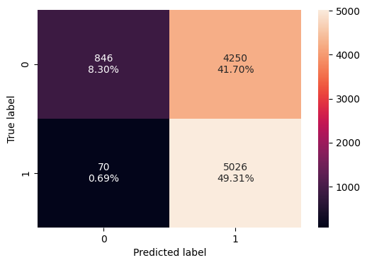

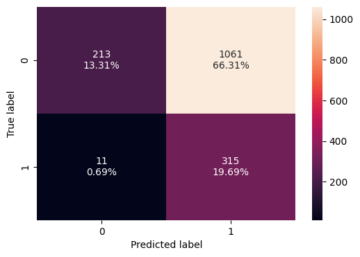

```python
#Predicting the results using 0.5 as the threshold - if not done, confusion matrix gives error
y_train_pred = model3.predict(X_train_smote)
y_train_pred = (y_train_pred > 0.5)
y_train_pred

#Predicting the results using 0.5 as the threshold
y_val_pred = model3.predict(X_valid)
y_val_pred = (y_val_pred > 0.5)
y_val_pred

#classification report on train set
cr=classification_report(y_train_smote, y_train_pred)
print(cr)

#classification report on validation set
cr=classification_report(y_valid, y_val_pred)
print(cr)

#Calculating the confusion matrix on train
make_confusion_matrix(y_train_smote, y_train_pred)

#confusion matrix on val
make_confusion_matrix(y_valid, y_val_pred)
```

### Model4 - Neural Network with Balanced Data (by applying SMOTE) and Adam Optimizer

```python
backend.clear_session()
np.random.seed(2)
random.seed(2)
tf.random.set_seed(2)

model4 = Sequential()
model4.add(Dense(64,activation='relu',input_dim = X_train_smote.shape[1]))
model4.add(Dense(32,activation='relu'))
model4.add(Dense(16,activation='relu'))
model4.add(Dense(1, activation = 'sigmoid'))
```

```python
model4.summary()
```

```
Model: "sequential"
_________________________________________________________________
 Layer (type)                Output Shape              Param #
=================================================================
 dense (Dense)               (None, 64)                768

 dense_1 (Dense)             (None, 32)                2080

 dense_2 (Dense)             (None, 16)                528

 dense_3 (Dense)             (None, 1)                 17

=================================================================
Total params: 3393 (13.25 KB)
Trainable params: 3393 (13.25 KB)
Non-trainable params: 0 (0.00 Byte)
_________________________________________________________________
```

```python
# Adam optrimiser
optimizer = tf.keras.optimizers.Adam()
model4.compile(optimizer = optimizer,loss = 'binary_crossentropy', metrics=[AUC(curve='ROC'), Recall()])
start = time.time()
history4 = model4.fit(X_train_smote, y_train_smote, validation_data=(X_valid,y_valid) , batch_size=batch_size, epochs=epochs,class_weight=cw_dict, verbose=1)
end=time.time()
```

```
Time taken in seconds  83.16544198989868
              precision    recall  f1-score   support

         0.0       0.98      0.47      0.63      5096
         1.0       0.65      0.99      0.78      5096

    accuracy                           0.73     10192
   macro avg       0.81      0.73      0.71     10192
weighted avg       0.81      0.73      0.71     10192

              precision    recall  f1-score   support

         0.0       0.95      0.46      0.62      1274
         1.0       0.30      0.90      0.45       326

    accuracy                           0.55      1600
   macro avg       0.62      0.68      0.53      1600
weighted avg       0.81      0.55      0.58      1600
```

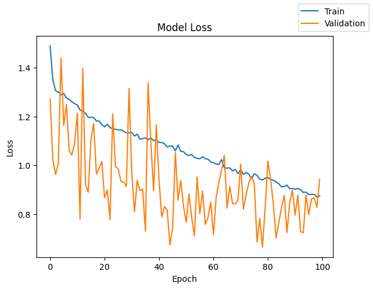

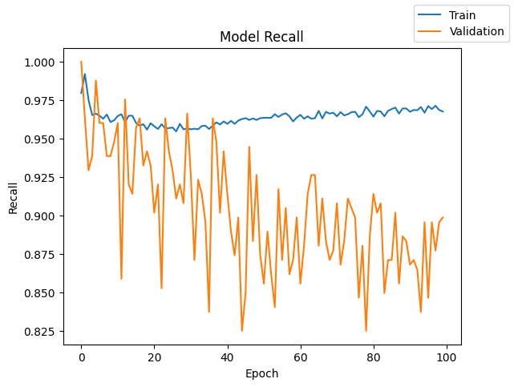

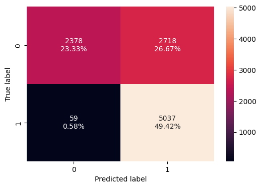

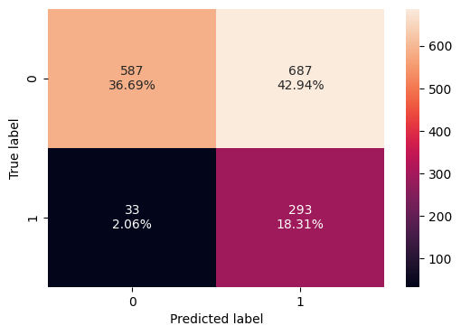

```python
print("Time taken in seconds ",end-start)
#Plotting Train Loss vs Validation Loss
plot(history4,'loss')
plot(history4,'recall')
model_4_train_perf = model_performance_classification(model4, X_train_smote, y_train_smote)
model_4_train_perf

model_4_valid_perf = model_performance_classification(model4, X_valid, y_valid)
model_4_valid_perf

#Predicting the results using 0.5 as the threshold - if not done, confusion matrix gives error
y_train_pred = model4.predict(X_train_smote)
y_train_pred = (y_train_pred > 0.5)
y_train_pred

#Predicting the results using 0.5 as the threshold
y_val_pred = model4.predict(X_valid)
y_val_pred = (y_val_pred > 0.5)
y_val_pred


#classification report on train set
cr=classification_report(y_train_smote, y_train_pred)
print(cr)

#classification report on validation set
cr=classification_report(y_valid, y_val_pred)
print(cr)

#Calculating the confusion matrix on train
make_confusion_matrix(y_train_smote, y_train_pred)

#confusion matrix on val
make_confusion_matrix(y_valid, y_val_pred)
```

### Model5- Neural Network with Balanced Data (by applying SMOTE), Adam Optimizer, and Dropout

```python
backend.clear_session()
#Fixing the seed for random number generators so that we can ensure we receive the same output everytime
np.random.seed(2)
random.seed(2)
tf.random.set_seed(2)
```

```python
#
model5 = Sequential()
#  input layer
model5.add(Dense(64,activation='relu',input_dim = X_train_smote.shape[1]))
#  dropout
model5.add(Dropout(0.2))
model5.add(Dense(32,activation='relu'))
#  dropout
model5.add(Dropout(0.1))
model5.add(Dense(16,activation='relu'))
model5.add(Dense(1, activation = 'sigmoid'))
```

```python
model5.summary()
```

```
Model: "sequential"
_________________________________________________________________
 Layer (type)                Output Shape              Param #
=================================================================
 dense (Dense)               (None, 64)                768

 dropout (Dropout)           (None, 64)                0

 dense_1 (Dense)             (None, 32)                2080

 dropout_1 (Dropout)         (None, 32)                0

 dense_2 (Dense)             (None, 16)                528

 dense_3 (Dense)             (None, 1)                 17

=================================================================
Total params: 3393 (13.25 KB)
Trainable params: 3393 (13.25 KB)
Non-trainable params: 0 (0.00 Byte)
_________________________________________________________________
```

```python
# Initializing Adam optimizer
optimizer = tf.keras.optimizers.Adam()
model5.compile(optimizer = optimizer,loss = 'binary_crossentropy', metrics=[AUC(curve='ROC'), Recall()])
start = time.time()

history5 = model5.fit(X_train_smote, y_train_smote, validation_data=(X_valid,y_valid) , batch_size=batch_size, epochs=epochs,class_weight=cw_dict, verbose=1)
end=time.time()
print("Time taken in seconds ",end-start)
```

```
Time taken in seconds  56.17085552215576
```

```
              precision    recall  f1-score   support

         0.0       0.96      0.55      0.70      5096
         1.0       0.68      0.98      0.81      5096

    accuracy                           0.76     10192
   macro avg       0.82      0.76      0.75     10192
weighted avg       0.82      0.76      0.75     10192

              precision    recall  f1-score   support

         0.0       0.96      0.53      0.69      1274
         1.0       0.33      0.90      0.48       326

    accuracy                           0.61      1600
   macro avg       0.64      0.72      0.59      1600
weighted avg       0.83      0.61      0.64      1600
```

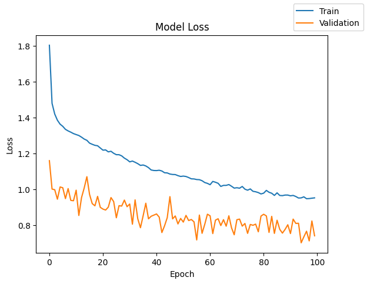

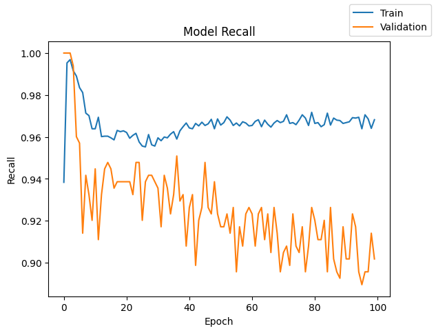

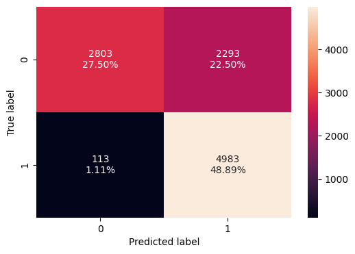

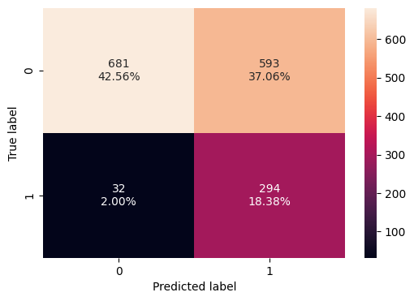

```python
#Plotting Train Loss vs Validation Loss
plot(history5,'loss')
plot(history5,'recall')
model_5_train_perf = model_performance_classification(model5, X_train_smote, y_train_smote)
model_5_train_perf

model_5_valid_perf = model_performance_classification(model5, X_valid, y_valid)
model_5_valid_perf

#Predicting the results using 0.5 as the threshold - if not done, confusion matrix gives error
y_train_pred = model5.predict(X_train_smote)
y_train_pred = (y_train_pred > 0.5)
y_train_pred

#Predicting the results using 0.5 as the threshold
y_val_pred = model5.predict(X_valid)
y_val_pred = (y_val_pred > 0.5)
y_val_pred


#classification report on train set
cr=classification_report(y_train_smote, y_train_pred)
print(cr)

#classification report on validation set
cr=classification_report(y_valid, y_val_pred)
print(cr)

#Calculating the confusion matrix on train
make_confusion_matrix(y_train_smote, y_train_pred)

#confusion matrix on val
make_confusion_matrix(y_valid, y_val_pred)
```

## Model Performance Comparison and Final Model Selection

```python
# training performance comparison

models_train_comp_df = pd.concat(
    [
        model_0_train_perf.T,
        model_1_train_perf.T,
        model_2_train_perf.T,
        model_3_train_perf.T,
        model_4_train_perf.T,
        model_5_train_perf.T
    ],
    axis=1,
)
models_train_comp_df.columns = [
    "Neural Network with SGD Optimizer",
    "Neural Network with Adam Optimizer",
    "Neural Network with Adam Optimizer and Dropout",
    "Neural Network with Balanced Data (by applying SMOTE) and SGD Optimizer",
    "Neural Network with Balanced Data (by applying SMOTE) and Adam Optimizer",
    "Neural Network with Balanced Data (by applying SMOTE), Adam Optimizer, and Dropout"
]
```

```python
#Validation performance comparison

models_valid_comp_df = pd.concat(
    [
        model_0_valid_perf.T,
        model_1_valid_perf.T,
        model_2_valid_perf.T,
        model_3_valid_perf.T,
        model_4_valid_perf.T,
        model_5_valid_perf.T
    ],
    axis=1,
)
models_valid_comp_df.columns = [
    "Neural Network with SGD Optimizer",
    "Neural Network with Adam Optimizer",
    "Neural Network with Adam Optimizer and Dropout",
    "Neural Network with Balanced Data (by applying SMOTE) and SGD Optimizer",
    "Neural Network with Balanced Data (by applying SMOTE) and Adam Optimizer",
    "Neural Network with Balanced Data (by applying SMOTE), Adam Optimizer, and Dropout"
]
```

```python
models_train_comp_df
```

|  | Neural Network with SGD Optimizer | Neural Network with Adam Optimizer | Neural Network with Adam Optimizer and Dropout | Neural Network with Balanced Data (by applying SMOTE) and SGD Optimizer | Neural Network with Balanced Data (by applying SMOTE) and Adam Optimizer | Neural Network with Balanced Data (by applying SMOTE), Adam Optimizer, and Dropout |
| --- | --- | --- | --- | --- | --- | --- |
| Accuracy | 0.683906 | 0.768750 | 0.777969 | 0.576138 | 0.727531 | 0.763932 |
| Recall | 0.683906 | 0.768750 | 0.777969 | 0.576138 | 0.727531 | 0.763932 |
| Precision | 0.810899 | 0.838232 | 0.832871 | 0.732705 | 0.812653 | 0.823051 |
| F1 Score | 0.714237 | 0.787616 | 0.794265 | 0.490426 | 0.707632 | 0.752615 |

```python
models_valid_comp_df
```

|  | Neural Network with SGD Optimizer | Neural Network with Adam Optimizer | Neural Network with Adam Optimizer and Dropout | Neural Network with Balanced Data (by applying SMOTE) and SGD Optimizer | Neural Network with Balanced Data (by applying SMOTE) and Adam Optimizer | Neural Network with Balanced Data (by applying SMOTE), Adam Optimizer, and Dropout |
| --- | --- | --- | --- | --- | --- | --- |
| Accuracy | 0.684375 | 0.771250 | 0.775625 | 0.330000 | 0.550000 | 0.609375 |
| Recall | 0.684375 | 0.771250 | 0.775625 | 0.330000 | 0.550000 | 0.609375 |
| Precision | 0.807978 | 0.834162 | 0.835102 | 0.803792 | 0.814786 | 0.828047 |
| F1 Score | 0.714532 | 0.789118 | 0.792740 | 0.301856 | 0.584980 | 0.644561 |

```python
models_train_comp_df.loc["Recall"] - models_valid_comp_df.loc["Recall"]
```

```
Neural Network with SGD Optimizer                                                    -0.000469
Neural Network with Adam Optimizer                                                   -0.002500
Neural Network with Adam Optimizer and Dropout                                        0.002344
Neural Network with Balanced Data (by applying SMOTE) and SGD Optimizer               0.246138
Neural Network with Balanced Data (by applying SMOTE) and Adam Optimizer              0.177531
Neural Network with Balanced Data (by applying SMOTE), Adam Optimizer, and Dropout    0.154557
Name: Recall, dtype: float64
```

Summary:

1. Since Recall is max in both the training set and validation set for "Neural Network with Adam Optimizer and Dropout" and
2. since the Recall value is also similar in case of Train and Validation sets,
3. F1 score in both training and validation sets is also max in this case

So: "Neural Network with Adam Optimizer and Dropout" is selected as the final model.

Next run the final model on test data:

```python
X_test = np.asarray(X_test).astype(np.float32)
y_test = np.asarray(y_test).astype(np.float32)


y_test_pred = model2.predict(X_test)
y_test_pred = (y_test_pred > 0.5)
print(y_test_pred)
```

```
[[False]
 [False]
 [False]
 ...
 [ True]
 [False]
 [False]]
```

```python
cr=classification_report(y_test, y_test_pred)
print(cr)
```

```
              precision    recall  f1-score   support

         0.0       0.92      0.78      0.85      1593
         1.0       0.46      0.74      0.57       407

    accuracy                           0.77      2000
   macro avg       0.69      0.76      0.71      2000
weighted avg       0.83      0.77      0.79      2000
```

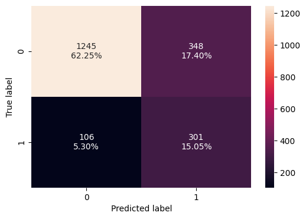

```python
make_confusion_matrix(y_test,y_test_pred)
```

## Actionable Insights and Business Recommendations

- Older people seem to exit more. Have promotions targeting older people
- It is not good that people with higher balance and higher numOfProducts seem to exit. They should be targeted for promotions, etc.
- Max percentage of people that exited are from Germany. It should be investigated what is the reason for this trend and explore targeted schemes in that region.
- The number of females exiting is also high. It should be checked why and take corrective actions
- The Percentage of Nonmembers exiting is more than members. Maybe some initiatives to educate the non-members of offers , plans, etc can be initiated.
- 75% of customers exiting are at tenure 8 years. Special incentives should be given to long-standing customers.